```r
library(ggplot2)
library(psych)
library(e1071)

dane1 <- read.csv("https://stooq.pl/q/d/l/?s=11b&d1=20220101&d2=20231231&i=d&o=1000000")
dane2 <- read.csv("https://stooq.pl/q/d/l/?s=ten&d1=20220101&d2=20231231&i=d&o=1000000")


dodanie_stopy <- function(dane){
  logarytmiczne_stopy <- c(NA)

  for(i in 2:(nrow(dane))) {
    logarytmiczne_stopy <- c(logarytmiczne_stopy, log(dane$Zamkniecie[i] / dane$Zamkniecie[i-1]))
  }

  dane$logarytmiczne_stopy <- logarytmiczne_stopy
  return(dane)
}


obliczenie_statystyk<- function(dane){
  srednia <- mean(dane$logarytmiczne_stopy, na.rm = TRUE)
  odchylenie_stand <- sd(dane$logarytmiczne_stopy, na.rm = TRUE)
  skosnosc <- skewness(dane$logarytmiczne_stopy, na.rm = TRUE)
  kurtoza <- kurtosis(dane$logarytmiczne_stopy, na.rm = TRUE)

  cat("Średnia:", srednia, "\n")
  cat("Odchylenie standardowe:", odchylenie_stand, "\n")
  cat("Skośność:", skosnosc, "\n")
  cat("Kurtoza:", kurtoza, "\n")
}

histogram <- function(dane) {

  ggplot(dane, aes(x = logarytmiczne_stopy)) +
    geom_histogram(binwidth = 0.01, fill = "lightblue", color = "darkblue", alpha = 0.7) +
    labs(title = "Histogram logarytmicznych stóp zwrotu", x = "Logarytmiczne stopy zwrotu") +
    theme_minimal()
}


wykres_pudelkowy <- function(dane) {

  ggplot(dane, aes(y = logarytmiczne_stopy)) +
    geom_boxplot(fill = "lightblue", color = "darkblue", alpha = 0.7) +
    labs(title = "Wykres pudełkowy logarytmicznych stóp zwrotu", y = "Logarytmiczne stopy zwrotu") +
    theme_minimal()
}

dane1 <- dodanie_stopy(dane1)
obliczenie_statystyk(dane1)
```

```
## Średnia: -4.749082e-05
## Odchylenie standardowe: 0.01952055
## Skośność: 0.09083402
## Kurtoza: 0.6843042
```

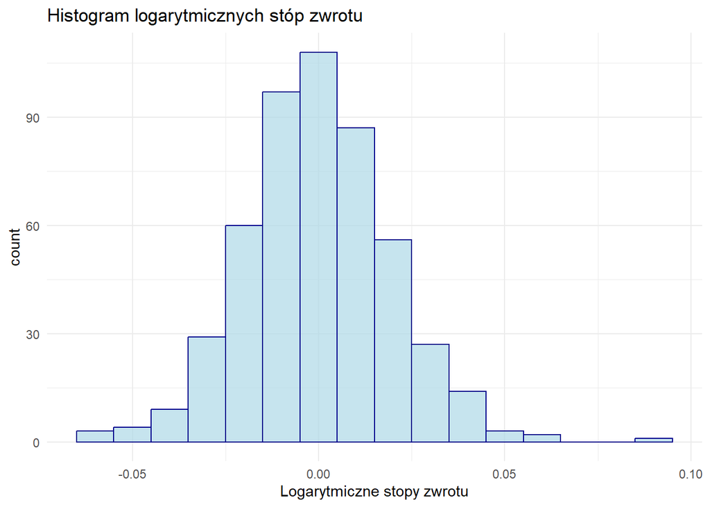

```r
histogram(dane1)
```

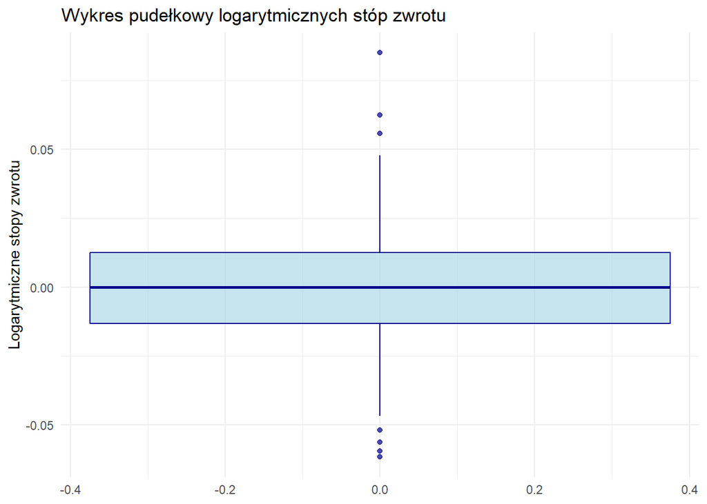

```r
wykres_pudelkowy(dane1)
```

```r
dane2 <- dodanie_stopy(dane2)
obliczenie_statystyk(dane2)
```

```
## Średnia: -0.002356371
## Odchylenie standardowe: 0.03618804
## Skośność: -0.4585796
## Kurtoza: 5.773356
```

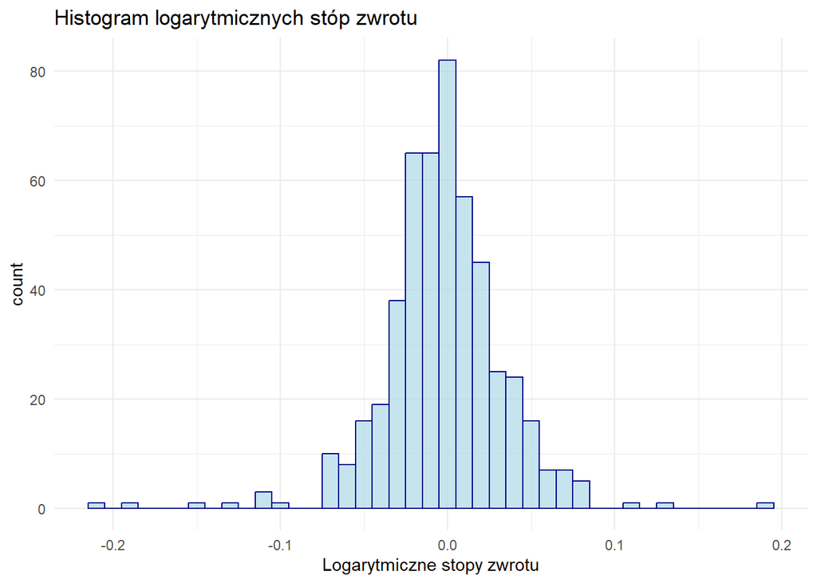

```r
histogram(dane2)
```

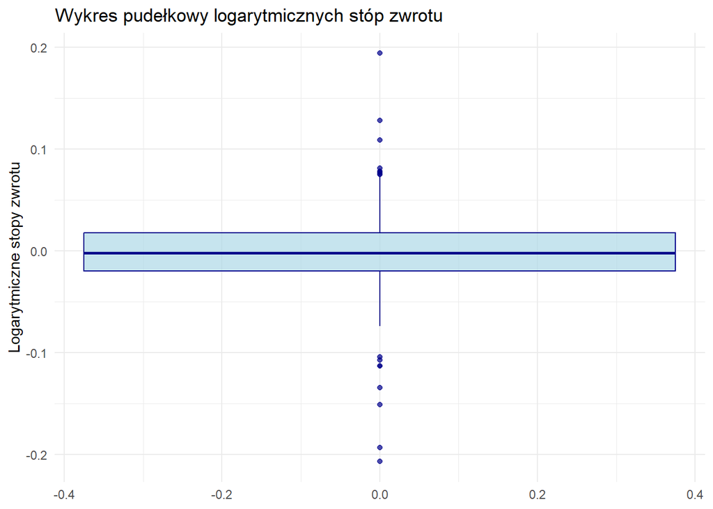

```r
wykres_pudelkowy(dane2)
```

## Testy istotności korelacji

```
## Współczynnik korelacji Pearsona:
## 0.1732326
##
## Test istotności korelacji Pearsona:
##
##  Pearson's product-moment correlation
##
## data:  dane1$logarytmiczne_stopy and dane2$logarytmiczne_stopy
## t = 3.9252, df = 498, p-value = 9.886e-05
## alternative hypothesis: true correlation is not equal to 0
## 95 percent confidence interval:
##  0.08686152 0.25701885
## sample estimates:
##       cor
## 0.1732326
##
## Współczynnik korelacji Spearmana:
## 0.1499769
##
## Test istotności korelacji Spearmana:
##
##  Spearman's rank correlation rho
##
## data:  dane1$logarytmiczne_stopy and dane2$logarytmiczne_stopy
## S = 17708744, p-value = 0.0007676
## alternative hypothesis: true rho is not equal to 0
## sample estimates:
##       rho
## 0.1499769
```

### Współczynniki korelacji wynoszą odpowiednio

- 0.1732326 dla współczynnika Pearsona
- 0.1499769 dla współczynnika Spermana

### Interpretacja testu istotności i współczynnika korelacji Pearsona:

- Współczynnik korelacji Pearsona wynosi 0.1732326, co oznacza, że związek liniowy między zmiennymi jest bardzo słaby i dodatni. Oznacza to, że gdy jedna zmienna rośnie, druga zmienna ma tendencję do wzrostu, ale w niewielkim stopniu.
- Test istotności korelacji Pearsona pokazuje, że p-value jest 9.886 * $10^{-5}$, co jest mniejsze niż poziom istotności 0.05. Oznacza to, że możemy odrzucić hipotezę zerową, że prawdziwa korelacja jest równa zero, i przyjąć hipotezę alternatywną, że prawdziwa korelacja jest różna od zera. Innymi słowy, istnieje istotna statystycznie korelacja liniowa między zmiennymi.
- Przedział ufności 95% dla korelacji Pearsona wynosi [0.08686152, 0.25701885], co oznacza, że jesteśmy pewni w 95%, że prawdziwa korelacja liniowa między zmiennymi mieści się w tym przedziale.

### Interpretacja testu istotności i współczynnika korelacji Spearmana:

- Współczynnik korelacji Spearmana wynosi 0.1499769, co oznacza, że związek monotoniczny między zmiennymi jest bardzo słaby i dodatni. Oznacza to, że gdy jedna zmienna rośnie, druga zmienna ma tendencję do wzrostu, ale niekoniecznie w sposób liniowy.
- Test istotności korelacji Spearmana pokazuje, że p-value jest 0.0007676, co jest mniejsze niż poziom istotności 0.05. Oznacza to, że możemy odrzucić hipotezę zerową, że prawdziwa korelacja jest równa zero, i przyjąć hipotezę alternatywną, że prawdziwa korelacja jest różna od zera. Innymi słowy, istnieje istotna statystycznie korelacja monotoniczna między zmiennymi.

## Test istotności różnicy wartości oczekiwanej

### Wartości oczekiwane zadanych rozkładów wynoszą odpowiednio

- -4.749082e * $10^{-5}$ dla danych nr. 1
- -0.002356371 dla danych nr. 2

```
## EX dla danych nr 1:
## -4.749082e-05
## EX dla danych nr 2:
## -0.002356371
##
##  Welch Two Sample t-test
##
## data:  dane1$logarytmiczne_stopy and dane2$logarytmiczne_stopy
## t = 1.2556, df = 766.72, p-value = 0.2096
## alternative hypothesis: true difference in means is not equal to 0
## 95 percent confidence interval:
##  -0.001300835  0.005918596
## sample estimates:
##     mean of x     mean of y
## -4.749082e-05 -2.356371e-03
```

> Interpretacja testu: Nie ma podstaw do odrzucenia hipotezy zerowej (H0), gdyż wartość p-value wynosi 0.2096, co jest większe niż przyjęty poziom istotności 0.05. Nie ma statystycznie istotnej różnicy między średnimi grup na poziomie istotności 0.05.